# HW#2

# P8)

Create a boxplot where “x axis” represents the Genre and “y axis” the Global Sales of the video game for a particular Genre. Make the text on “x” axis vertical (Hint! ?theme, ?element_text). Make some comments.(2p)

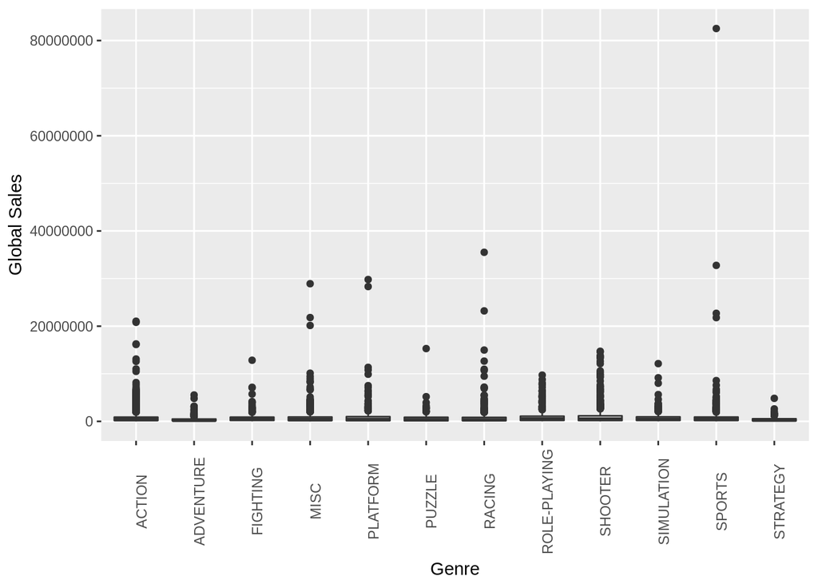

```r
ggplot(games, aes(x = Genre, y = Global_Sales)) + geom_boxplot() +
  theme(axis.text.x = element_text(angle=90)) +
  labs(y = "Global Sales")
```

# P9)

Zoom the previous plot (Numbers on “y” axis (0,2million)) to clearly see the boxplots for each Genre and make comments. (1p)

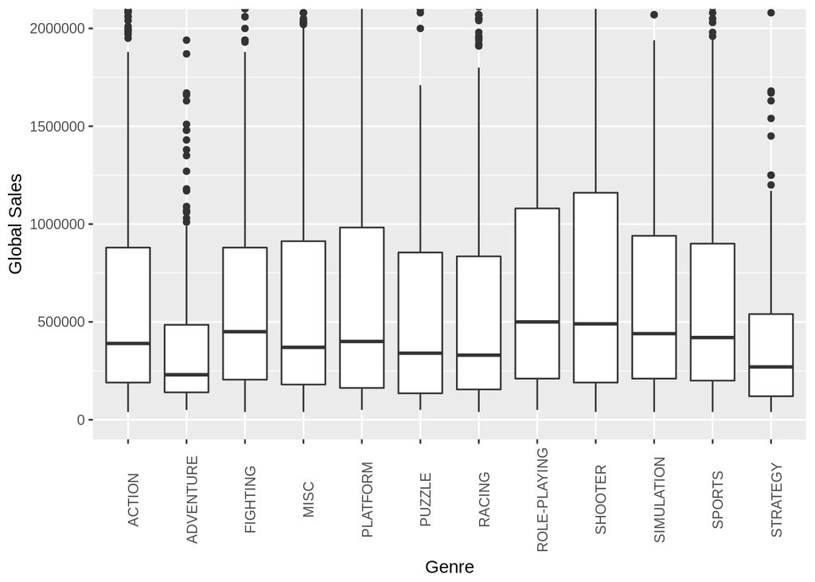

```r
ggplot(games, aes(x = Genre, y = Global_Sales)) + geom_boxplot() +
  theme(axis.text.x = element_text(angle=90)) +
  labs(y = "Global Sales") +
  coord_cartesian(ylim = c(0,2000000))
```

## As we can see the shooter games almost have the highest sales but overall they are all pretty close to each other

# P10)

Create a barplot using dyplr functionalities and faceting to show the total Global Sales for each year for each Rating. (2p)

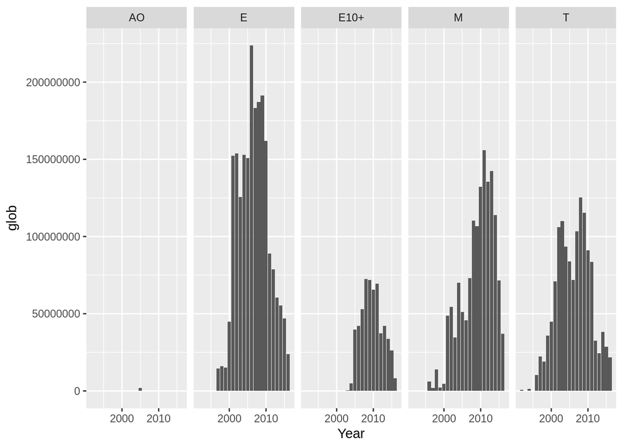

```r
games %>%
  group_by(Year, Rating) %>%
  summarise(glob = sum(Global_Sales)) %>%
  ggplot(aes(x = Year, y = glob)) +geom_bar(stat="identity") +
  facet_grid(.~Rating)
```

# P11)

Use the pipe operator and functions from dplyr package and show the number of video games in each genre in descending order. (2p)

```r
number_eleven <- games %>%
  group_by(Genre) %>%
  summarise(num = n_distinct(Name)) %>%
  arrange(desc(num))

number_eleven
```

```
## # A tibble: 12 x 2
##    Genre          num
##    <chr>        <int>
##  1 ACTION         784
##  2 SPORTS         498
##  3 SHOOTER        420
##  4 ROLE-PLAYING   386
##  5 RACING         360
##  6 MISC           329
##  7 PLATFORM       256
##  8 SIMULATION     212
##  9 FIGHTING       207
## 10 ADVENTURE      175
## 11 STRATEGY       121
## 12 PUZZLE         100
```

# P12)

Use dplyr to create a new variable (CU_Score) in Video dataset which for each video game will show the average of Critic score and 10* User Score. (2p)

```r
games <- games %>%
  mutate(CU_User = ((User_Score * 10) + Critic_Score)/2)
```

# P13)

Use the pipe operator and functions from dplyr package to find the top 3 platforms and the number of video games developed for each of them. (2p)

```r
# Top platform is by how average sale and not the quantity of games
best_platforms <- games %>%
  group_by(Platform) %>%
  summarise(sales_mean = mean(Global_Sales),
            num_of_games = n_distinct(Name))

best <- best_platforms %>%
  top_n(best_platforms$sales_mean, n= 3)
```

# P14)

We are interested in the number of video games developed for top platforms for different years. Pick the top 3 platforms from previous problem and make other platforms as “Other” using dplyr (Hint! ifelse statement). Thereafter remove observations from dataframe which have NA values (Hint! ?complete.cases).Now use faceting to draw the distribution of games for each year for each platform. Make text on “x” axis vertical and size=6. Make comments how the number of video games changed for each platform for different years.(4p)

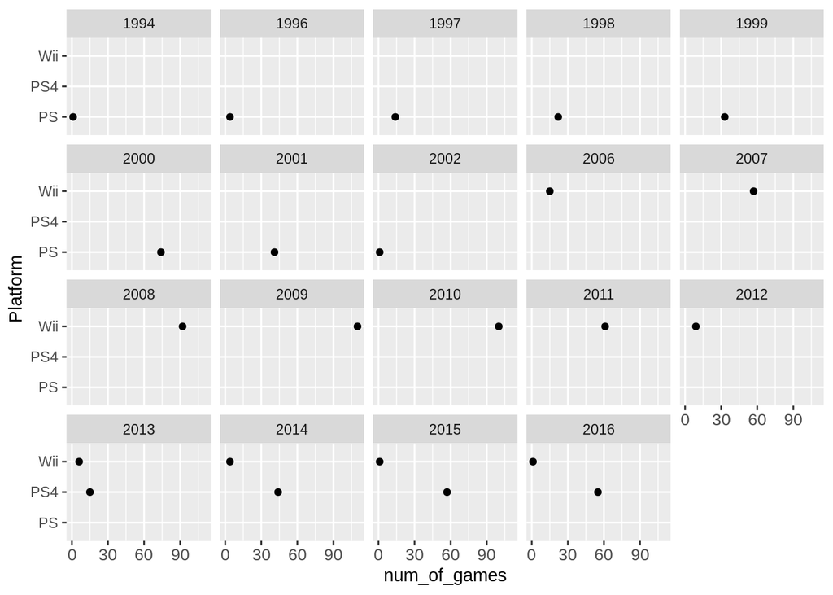

```r
best_platforms_y <- games %>%
  group_by(Platform, Year, add = T) %>%
  summarise(sales_mean = mean(Global_Sales),
            num_of_games = n_distinct(Name))

top_notch <- best_platforms_y %>%
  group_by(Platform) %>%
  filter(Platform %in% best$Platform)

top_notch <- top_notch[complete.cases(top_notch), ]

ggplot(top_notch, aes(x = num_of_games, y = Platform)) + geom_point() +
  facet_wrap(~Year, ncol= 5) +
  theme(axis.text.x = element_text(size = 10))
```